# Spatial data in R

# 5 Making maps with sf objects

## 5.1 By using ggplot2

The ggplot2 package (Wickham, Chang, et al. 2022) allows to create graphics based on the grammar of graphics, allowing users to build plots layer by layer.

To create a plot with ggplot2, call *ggplot()* specifying arguments data which is a data frame with the variables to plot, and mapping *+aes()* which are aesthetic mappings between variables in the data and visual properties of the objects in the graph such as position and color of points or lines.

Use *+* to add layers of graphical components to the graph.

Add objects to the graph with *geom_*()* functions (e.g, *geom_point()* for points, *geom_line()* for lines).

You can create maps by using the *geom_sf()* function and providing a simple feature *sf* object.

The script below prints the map of variable *SID74* (sudden infant deaths) from the North Carolina SIDS data set *nc {sf}*.

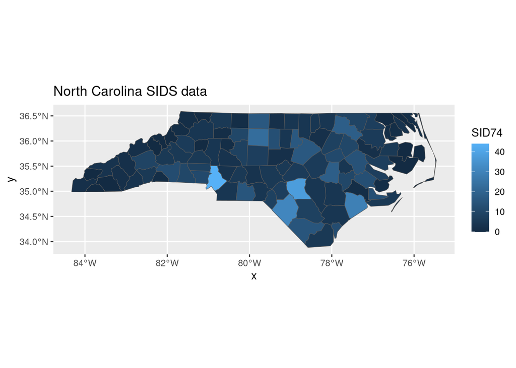

```r
rm( list = ls() )
#
# Load spatial data
#
library(sf)
path.to.nc.shp <- system.file("shape/nc.shp",
                       package = "sf")
nc.map <- st_read(path.to.nc.shp,
               quiet = TRUE)
#
# Load package
#
library(ggplot2)
#
# Create an   Map for the attribute SID74
#
ggplot(nc.map) +                   # sf object holding the spatial data to be plotted
  geom_sf(aes(fill = SID74)) +     # the name of the variable I wish to map as colour
  ggtitle("North Carolina SIDS data") +
  xlab("x") +
  ylab("y")
```

*Task*

Edit the script with purpose to map attribute *lead* from dataset *meuse {sp}* .

Hint: Use crs code 28992 .

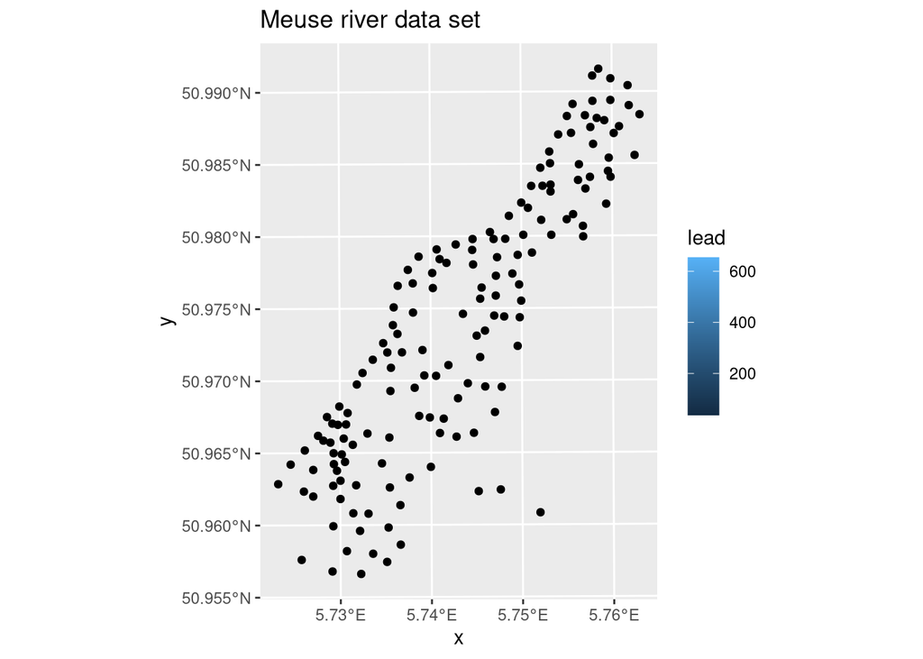

```r
rm( list = ls() )
#
# Load spatial data
#
library(sp)
data(meuse)
meuse <- st_as_sf(meuse,
                  coords = c("x", "y"),      # specify which columns are the coordinates
                  crs = 28992                # CRS code
                  )
meuse.map <- meuse
#
# Write your code below
#
#
# Load package
#
library(ggplot2)
#
# Create the map for the attribute SID74
#
ggplot(meuse.map) +                   # sf object holding the spatial data to be plotted
  geom_sf(aes(fill = lead)) +
  ggtitle("Meuse river data set") +
  xlab("x") +
  ylab("y")
```

## 5.2 By using mapview

R package *mapview* (Appelhans et al. 2022) allows to create interactive maps.

We just need to use the *mapview()* function passing as arguments the spatial object and the variable we want to plot.

Some arguments:

- *zcol=* specifies the attribute to be plotted
- *map.types=* the base maps. Some options can be found by running *mapviewGetOption(“basemaps”)*.

The following script creates an interactive map with the variable *SID74*.

```r
rm( list = ls() )
#
# Load spatial data
#
library(sf)
path.to.nc.shp <- system.file("shape/nc.shp",
                       package = "sf")
nc.map <- st_read(path.to.nc.shp,
               quiet = TRUE)
#
# Load package
#
library(mapview)
#
# Create an Interactive Map for the attribute SID74
#
mapview(nc.map,        # sf object holdign the spatial data to be plotted
        zcol = "SID74", # attribute name(s) or column number(s) in attribute table of the column(s) to be rendered.
        map.types = "CartoDB.Positron")
```

[interactive chart not shown]

*Task*

The script below used *meuse{spdep}* dataset.

Edit the script with purpose to draw a basic interactive map for the attribute *lead*.

For *map.types=* use a value different than *“CartoDB.Positron”*

Hint: Use CRS code 28992 .

```r
rm( list = ls() )
#
# Load spatial data
#
library(sp)
data(meuse)
meuse <- st_as_sf(meuse,
                  coords = c("x", "y"),      # specify which columns are the coordinates
                  crs = 28992  # CRS code
                  )
#
# Load package
#
library(mapview)
#
# Write your code below
#
meuse.map <- meuse
head(meuse.map)
```

|  | cadmium | copper | lead | zinc | elev | dist | om | ffreq | soil | lime | landuse | dist.m | geometry |
| --- | --- | --- | --- | --- | --- | --- | --- | --- | --- | --- | --- | --- | --- |
| 1 | 11.7 | 85 | 299 | 1022 | 7.909 | 0.00135803 | 13.6 | 1 | 1 | 1 | Ah | 50 |  |
| 2 | 8.6 | 81 | 277 | 1141 | 6.983 | 0.01222430 | 14.0 | 1 | 1 | 1 | Ah | 30 |  |
| 3 | 6.5 | 68 | 199 | 640 | 7.800 | 0.10302900 | 13.0 | 1 | 1 | 1 | Ah | 150 |  |
| 4 | 2.6 | 81 | 116 | 257 | 7.655 | 0.19009400 | 8.0 | 1 | 2 | 0 | Ga | 270 |  |
| 5 | 2.8 | 48 | 117 | 269 | 7.480 | 0.27709000 | 8.7 | 1 | 2 | 0 | Ah | 380 |  |
| 6 | 3.0 | 61 | 137 | 281 | 7.791 | 0.36406700 | 7.8 | 1 | 2 | 0 | Ga | 470 |  |

```r
mapviewGetOption("basemaps")
## [1] "CartoDB.Positron"   "CartoDB.DarkMatter" "OpenStreetMap"
## [4] "Esri.WorldImagery"  "OpenTopoMap"
#
# Create an Interactive Map for the attribute SID74
#
mapview(meuse.map,        # sf object holdign the spatial data to be plotted
        zcol = "lead", # attribute name(s) or column number(s) in attribute table of the column(s) to be rendered.
        map.types = "OpenTopoMap")
```

[interactive chart not shown]

### 5.2.1 By using tmap

R package *tmap* (Tennekes 2022) creates static and interactive maps composed of multiple shapes and layers, and with different styles. Syntax is similar to that of ggplot2.

Maps are created with *tm_shape()* specifying the *sf* object.

Layers are added with a *+tm_*()* function. For example, *+tm_polygons()* draws polygons, *+tm_dots()* draws dots, and *+tm_text()* adds text. Basemap can be set by adding *+tm_basemap()* whose values are available from https://leaflet-extras.github.io/leaflet-providers/preview/

Functions *tmap_mode(“plot”)* and *tmap_mode(“view”)* can be used to set the *static* and *interactive* modes of the maps respectively.

Function *tmap_save()* can be used to save maps by specifying the name of the *HTML* file (if view mode) or *image* (if plot mode).

For more run *?tmap*.

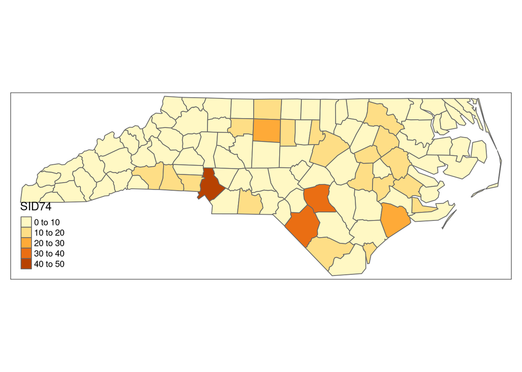

```r
rm(list = ls())
#
# Get the spatial data
#
library(sf)
pathshp <- system.file("shape/nc.shp", package = "sf")
nc.data <- st_read(pathshp, quiet = TRUE)
nc.map <- nc.data
#
# Load the library
#
library(tmap)
#
# Set the mode: "plot" or "view"
#
tmap_mode("plot")
#
# Create the thematic map
#
tm_shape(nc.map) +
  tm_polygons("SID74")
```

*Task*

Edit the script with purpose to draw a basic interactive map for the attribute *lead* in data set *meuse{spdep}*.

For *+tm_basemap( )* use a value *“CyclOSM”* Other options are available from

- https://leaflet-extras.github.io/leaflet-providers/preview/

Hint: Use crs code 28992 .

```r
rm(list = ls())
library(sp)
library(sf)
library(gstat)
data(meuse)
meuse <- st_as_sf(meuse,
                  coords = c("x", "y"),      # specify which columns are the coordinates
                  crs = 28992  # CRS code
                  )
#
# Write your R code below
#
meuse.map <- meuse
#
# Basic Usage
#
library(tmap)
#
# Set the mode:
#
tmap_mode("view")
#
# Create the thematic map
#
tm_shape(meuse.map) +
  tm_dots("lead") +
  tm_basemap("CyclOSM")
```

[interactive chart not shown]

# 6 Transforming point data to sf object

We wish to create a *sf* object from a data.frame containing the coordinates of locations and attributes.

To do that, use the function *st_as_sf{sf}* passing the object you wish to convert and specifying in argument *coords* the name of the data.frame columns containing the point coordinates.

Steps:

1. use *data.frame()* to save the spatial data in a standard data.frame containing coordinates long and lat and two variables place and value.
2. use function *st_as_sf{sf}* to turn a data.frame to a *sf* object.
3. use function *st_crs{sf}* to set the coordinate reference system (CRS) to represent longitude and latitude coordinates.
- Coordinate reference system (CRS) defines, with the help of coordinates, how the two-dimensional, projected map is related to real locations on the earth. In our course the code for CRS will be given.

The following script transforms some spatial data in data.frame form into sf object with CRS given by the EPSG code 4326.

```r
rm(list=ls())
#
# Create data frame
#
df.data <- data.frame(
  place = c("London", "Paris", "Madrid", "Rome"),
  long = c(-0.118092, 2.349014, -3.703339, 12.496366),
  lat = c(51.509865, 48.864716, 40.416729, 41.902782),
  value = c(200, 300, 400, 500))
class(df.data)
## [1] "data.frame"
#
# Load the library
#
library(sf)
#
# transform data.frame into sf object
#
sf.data <- st_as_sf( x = df.data,          #  enter data
                 coords = c("long", "lat"), # specify the coordinates
                 crs = 4326
                 )
st_crs(sf.data) <- 4326
#
# Plot
#
mapview(sf.data)
```

[interactive chart not shown]

*Task*

Transform the following data.frame into sf object. Then produce a map of the variable *logtotalCatch* by using mapview.

Hint: For CRS use 4326

```r
rm( list = ls() )

library(HRW)
data(scallop)
scallop$logtotalCatch <- log(scallop$totalCatch+1.0)
#
# Write your code below
#
#
# Load the library
#
library(sf)
#
df.data <- scallop
#
# transform data.frame into sf object
#
sf.data <- st_as_sf( x = df.data,                     #  enter data
                 coords = c("longitude", "latitude"), # specify the coordinates
                 crs = 4326                           # set the CRS code
                 )
#st_crs(sf.data) <- 4326
#
# Plot
#
mapview(sf.data,
        zcol = "logtotalCatch")
```

[interactive chart not shown]

# 7 Creating sf objects (more advanced)

Recall that a *sf* object contains the following objects of class *sf*, *sfc* and *sfg*.

Simple feature geometries *sfg objects* can be of type *POINT (single point)*, *MULTIPOINT (set of points)* or *POLYGON (polygon)*, and can be created with *st_point()*, *st_multipoint()* and *st_polygon()*.

Function *st_sf{sf}* creates an *sf* object by providing a *data.frame* with the attributes of each feature, and a simple feature geometry list-column *sfc* containing simple feature geometries *sfg*.

General steps:

1. create the simple feature geometry objects *sfg* of type *POINT*, *MULTIPOINT*, and *POLYGON*.
2. use *st_sfc()* to create a simple feature geometry list-column *sfc* with the *sfg* objects.
3. use *st_sf()* to put the *data.frame* with the attribute and the simple feature geometry list-column *sfc* together.

The script below creates a *sf* object containing *two single points*, *a set of points*, and *a polygon*, with one attribute. Then it maps the object via ggplot2 for you to see the result.

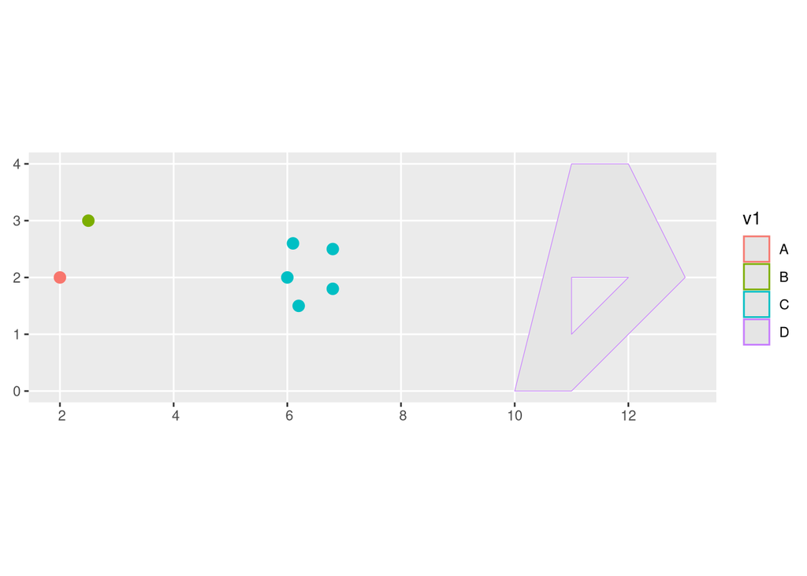

```r
rm( list = ls() )
library(sf)
#
# STEP 1
#
# Single point (point as a vector)
p1_sfg <- st_point(c(2, 2))     # a point
p2_sfg <- st_point(c(2.5, 3))   # a point
#
# Set of points (points as a matrix)
p <- rbind(c(6, 2), c(6.1, 2.6), c(6.8, 2.5),
           c(6.2, 1.5), c(6.8, 1.8))
mp_sfg <- st_multipoint(p)      # several points defined together
#
# Polygon. Sequence of points that form a closed,
# non-self intersecting ring.
# The first ring denotes the exterior ring,
# zero or more subsequent rings denote holes in the exterior ring
p1 <- rbind(c(10, 0), c(11, 0), c(13, 2),
            c(12, 4), c(11, 4), c(10, 0))           # exterior ring
p2 <- rbind(c(11, 1), c(11, 2), c(12, 2), c(11, 1)) # interior ring
pol_sfg <- st_polygon(list(p1, p2))
#
# STEP 2
#
# Create sf object
p_sfc <- st_sfc(p1_sfg,
                p2_sfg,
                mp_sfg,
                pol_sfg
                )
#
# STEP 3
#
df <- data.frame( v1 = c("A", "B", "C", "D") ) # the attributes
p_sf <- st_sf(df,                              # the attributes
              geometry = p_sfc                 # the geometry
              )
#
# Plot them (to be introduced later in the computer practical)
#
library(ggplot2)
ggplot(p_sf) +
  geom_sf( aes( col = v1 ), size = 3)
```

```r
# plot(p_sf)
```

*Task*

Then plot the sf object.

Hint: You can just edit the above script

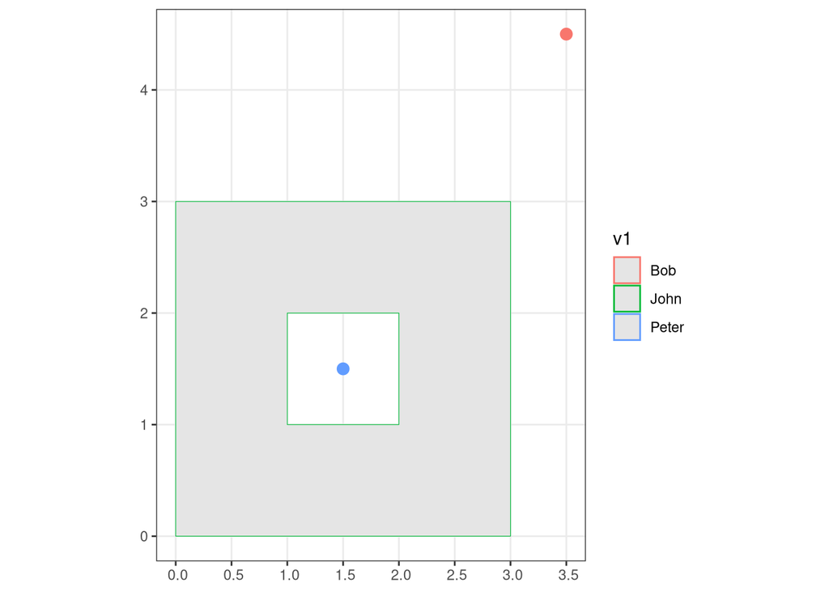

```r
rm( list = ls() )
#
# Write your code below
#
library(sf)
#
# STEP 1
#
# Single point (point as a vector)
p1_sfg <- st_point(c(1.5,1.5))     # a point
p2_sfg <- st_point(c(3.5,4.5))   # a point
#
# # Set of points (points as a matrix)
# p <- rbind(c(6, 2), c(6.1, 2.6), c(6.8, 2.5),
#            c(6.2, 1.5), c(6.8, 1.8))
# mp_sfg <- st_multipoint(p)      # several points defined together
#
# Polygon. Sequence of points that form a closed,
# non-self intersecting ring.
# The first ring denotes the exterior ring,
# zero or more subsequent rings denote holes in the exterior ring
p1 <- rbind(c(0, 0), c(0, 3), c(3, 3), c(3,0), c(0,0) )   # exterior ring
p2 <- rbind(c(1, 1), c(1, 2), c(2, 2), c(2, 1), c(1, 1)) # interior ring
pol_sfg <- st_polygon(list(p1, p2))
#
# STEP 2
#
# Create sf object
p_sfc <- st_sfc(p1_sfg,
                p2_sfg,
                # mp_sfg,
                pol_sfg
                )
#
# STEP 3
#
df <- data.frame( v1 = c("Peter", "Bob", "John") ) # the attributes
p_sf <- st_sf(df,
              geometry = p_sfc)
#
# Plot them (to be introduced later in the computer practical)
#
library(ggplot2)
ggplot(p_sf) +
  geom_sf(aes( col = v1 ), size = 3) +
  theme_bw()
```

# 8 Deleting and combining polygons

Let *nc.map* be the *sf* object.

The following script creates *nc.map.1* from *nc.map* by removing polygons (areas) associated with the FIPS values “37125”, “37051”.

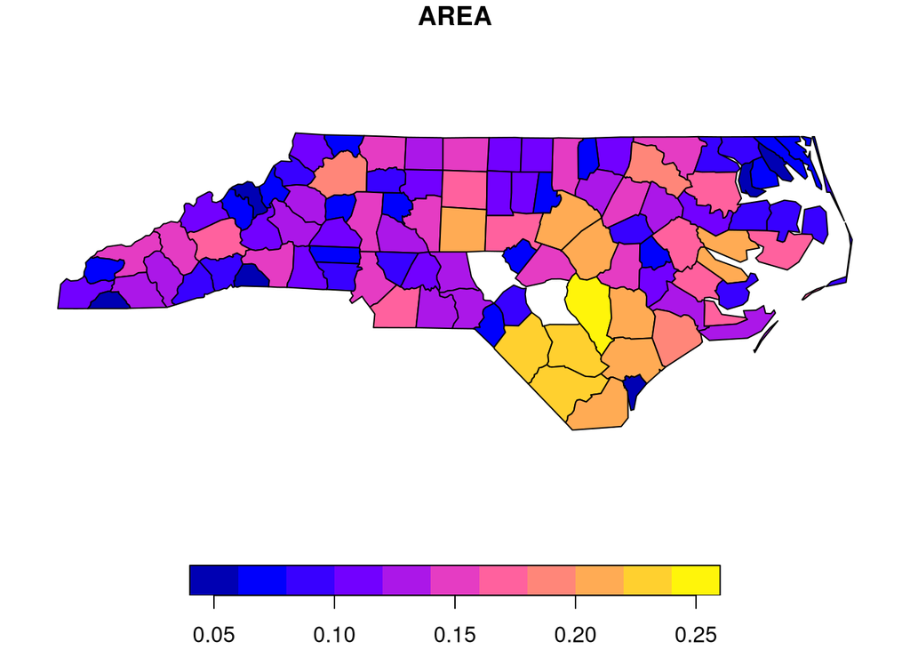

```r
rm( list = ls() )
library(sf)
path.to.nc.shp <- system.file("shape/nc.shp",
                       package = "sf")
nc.map <- st_read(path.to.nc.shp,
               quiet = TRUE)
#
# Delete polygon
#
nc.map.1 <- nc.map[-which(nc.map$FIPS %in% c("37125", "37051")), ]
#
# Plot it
#
plot(nc.map.1["AREA"])
```

The following script creates *nc.map.2* as a union of all *nc.map.1* polygons (remember we had removed some)

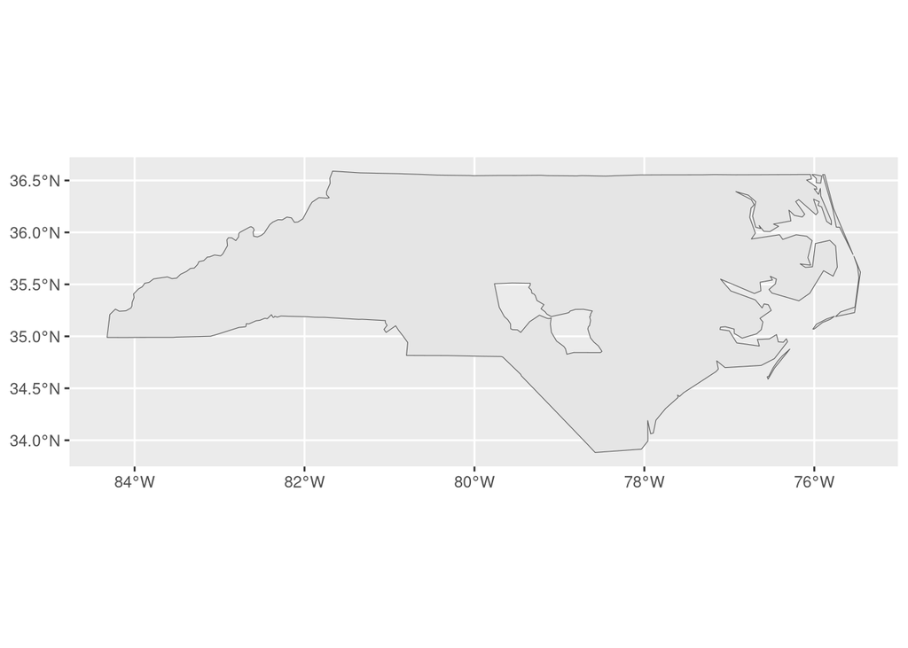

```r
#
# Union
#
nc.map.2 <- st_union(nc.map.1, by_feature = FALSE)
nc.map.2 <- st_sf( nc.map.2 )
#
# Plot it
#
ggplot(st_union(nc.map.2, by_feature = FALSE)) +
  geom_sf()
```

*Task*

Edit the script below, to create an *sf* object from *nc.map* where the counties with *NAME* values *Durham*, *Northampton*, and *Stokes* are removed. Then plot the object.

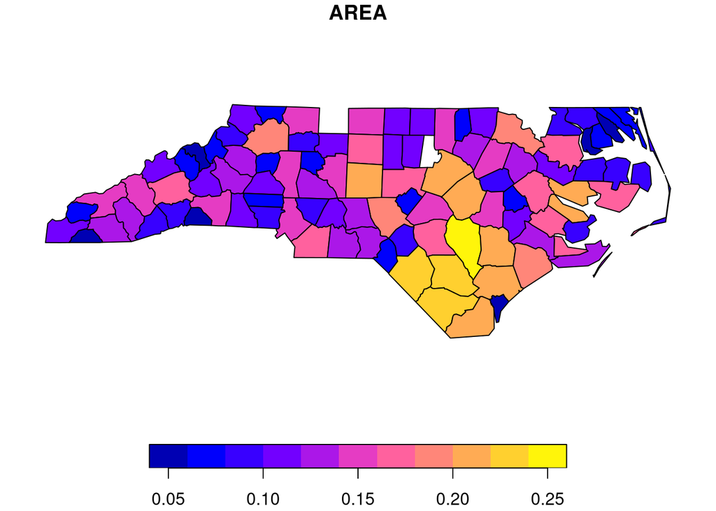

```r
rm( list = ls() )
library(sf)
path.to.nc.shp <- system.file("shape/nc.shp",
                       package = "sf")
nc.map <- st_read(path.to.nc.shp,
               quiet = TRUE)
#
# Write your code below
#
#
# Delete polygon
#
nc.map.1 <- nc.map[-which(nc.map$NAME %in% c("Durham", "Northampton", "Stokes")), ]
#
# Plot it
#
plot(nc.map.1["AREA"])
```

# 9 Counting the number of points within polygons

The following script:

1. uses function *st_sample {sf}* to sample random points at locations in the map.
2. uses function *st_intersects{sf}* to count the number of points within the polygons of a *sf* object. The returned object is a list with feature ids intersected in each of the polygons.
3. uses function *lengths{sf}* to calculate the number of points inside each feature.

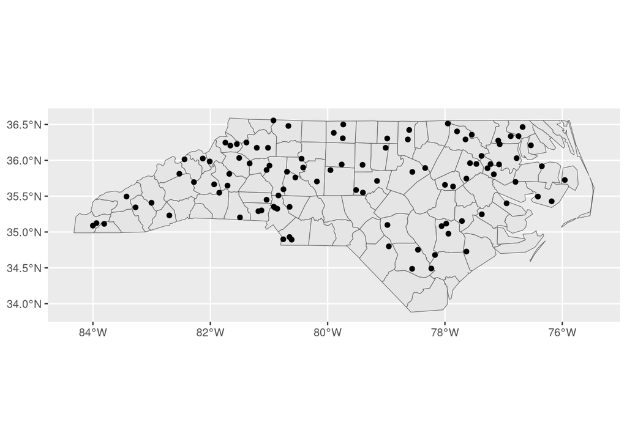

```r
rm(list=ls())
library(sf)
# Map with divisions (sf object)
nc.map <- read_sf(system.file("shape/nc.shp",
                              package = "sf")
                  )
#
# 1
#
# Points over map (simple feature geometry list-column sfc)
nc.points <- st_sample(nc.map,
                    size = 100)

# Map of points within polygons
ggplot() +
  geom_sf(data = nc.map) +
  geom_sf(data = nc.points)
```

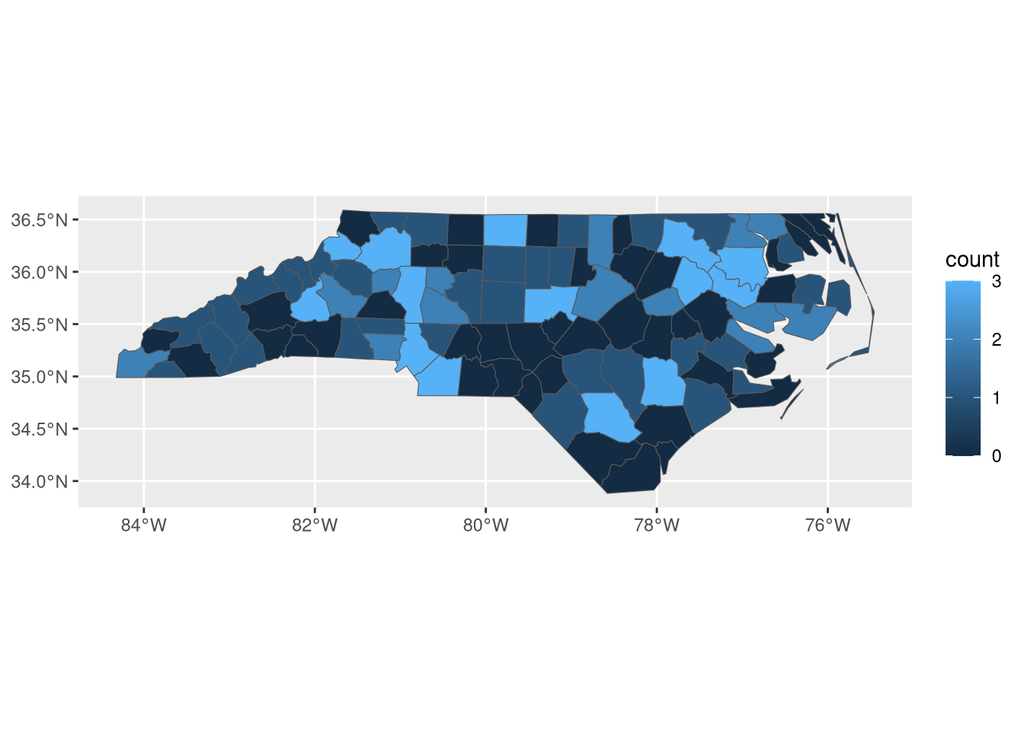

```r
#
# 2
#
# Intersection (first argument map, then points)
nc.inter <- st_intersects(nc.map, nc.points)
#
# 3
#
# Add point count to each polygon
nc.map$count <- lengths(nc.inter)

# Map of number of points within polygons
library(ggplot2)
ggplot(nc.map) + geom_sf(aes(fill = count))
```

*Task*

Edit the script below and count the number of points in North carolina area whose *AREA* is smaller than 0.1 only.

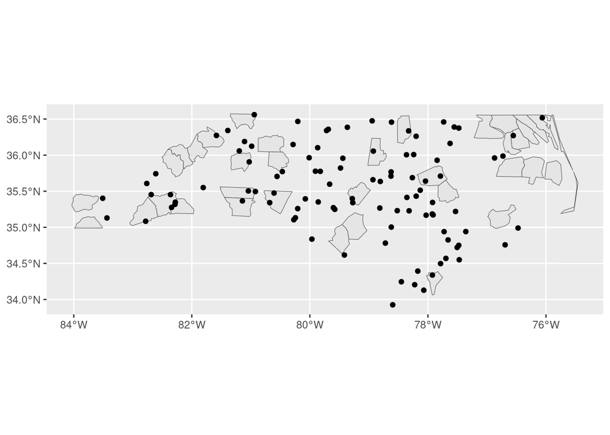

```r
rm(list=ls())
library(sf)
# Map with divisions (sf object)
nc.map <- read_sf(system.file("shape/nc.shp",
                              package = "sf")
                  )
#
# 1
#
# Points over map (simple feature geometry list-column sfc)
nc.points <- st_sample(nc.map,
                    size = 100)


#
# Write your code below
#

nc.map <- nc.map[-which(nc.map$AREA>0.1), ]

# Map of points within polygons
ggplot() +
  geom_sf(data = nc.map) +
  geom_sf(data = nc.points)
```

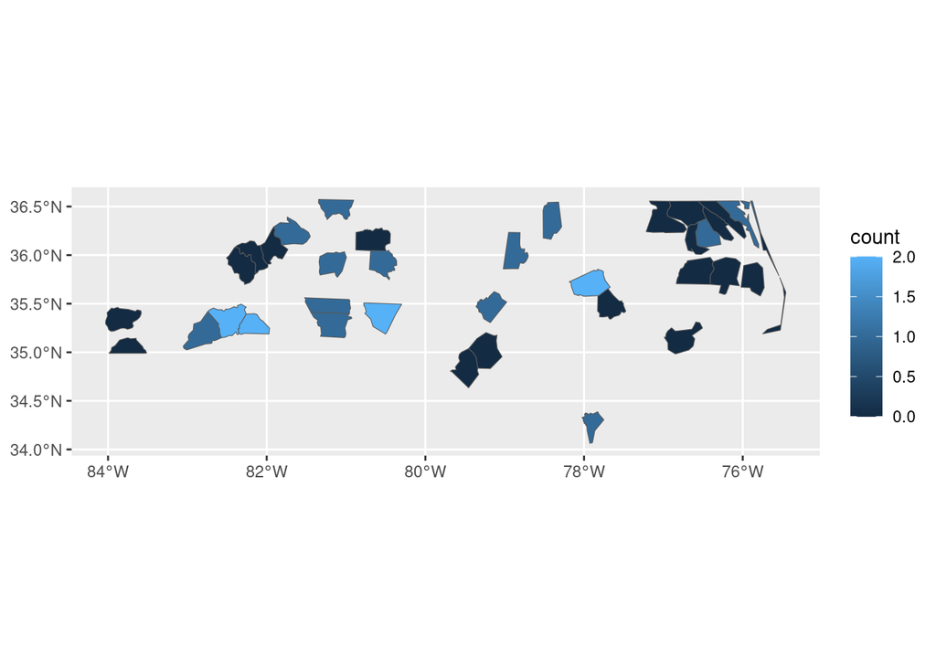

```r
#
# 2
#
# Intersection (first argument map, then points)
nc.inter <- st_intersects(nc.map, nc.points)
#
# 3
#
# Add point count to each polygon
nc.map$count <- lengths(nc.inter)

# Map of number of points within polygons
library(ggplot2)
ggplot(nc.map) + geom_sf(aes(fill = count))
```

```r
#
print(nc.map[,c("NAME","count")])
## Simple feature collection with 35 features and 2 fields
## Geometry type: MULTIPOLYGON
## Dimension:     XY
## Bounding box:  xmin: -84.03086 ymin: 34.06203 xmax: -75.45698 ymax: 36.57286
## Geodetic CRS:  NAD27
## # A tibble: 35 × 3
##    NAME       count                                                     geometry
##    <chr>      <int>                                           <MULTIPOLYGON [°]>
##  1 Alleghany      1 (((-81.23989 36.36536, -81.24069 36.37942, -81.26284 36.405…
##  2 Currituck      1 (((-76.00897 36.3196, -76.01735 36.33773, -76.03288 36.3359…
##  3 Hertford       0 (((-76.74506 36.23392, -76.98069 36.23024, -76.99475 36.235…
##  4 Camden         0 (((-76.00897 36.3196, -75.95718 36.19377, -75.98134 36.1697…
##  5 Gates          0 (((-76.56251 36.34057, -76.60424 36.31498, -76.64822 36.315…
##  6 Vance          1 (((-78.49252 36.17359, -78.51472 36.17522, -78.51709 36.461…
##  7 Pasquotank     0 (((-76.29893 36.21423, -76.32423 36.23362, -76.37242 36.252…
##  8 Watauga        1 (((-81.80622 36.10456, -81.81715 36.10939, -81.82231 36.157…
##  9 Perquimans     1 (((-76.48053 36.07979, -76.53696 36.08792, -76.5756 36.1026…
## 10 Chowan         0 (((-76.68874 36.29452, -76.64822 36.31532, -76.60424 36.314…
## # ℹ 25 more rows
```